# Welling_Spatial_Statistics_Assignment

## Spatial Modeling Assignment

```r
library(vegan)
library(nlme)
library(vegan)
data(BCI)
## UTM Coordinates (in metres)
BCI_xy = data.frame(x = rep(seq(625754, 626654, by=100), each=5),
                    y = rep(seq(1011569,  1011969, by=100), len=50))
```

1. Examine if there is evidence of spatial dependence in a rare and a common species in the BCI tree dataset

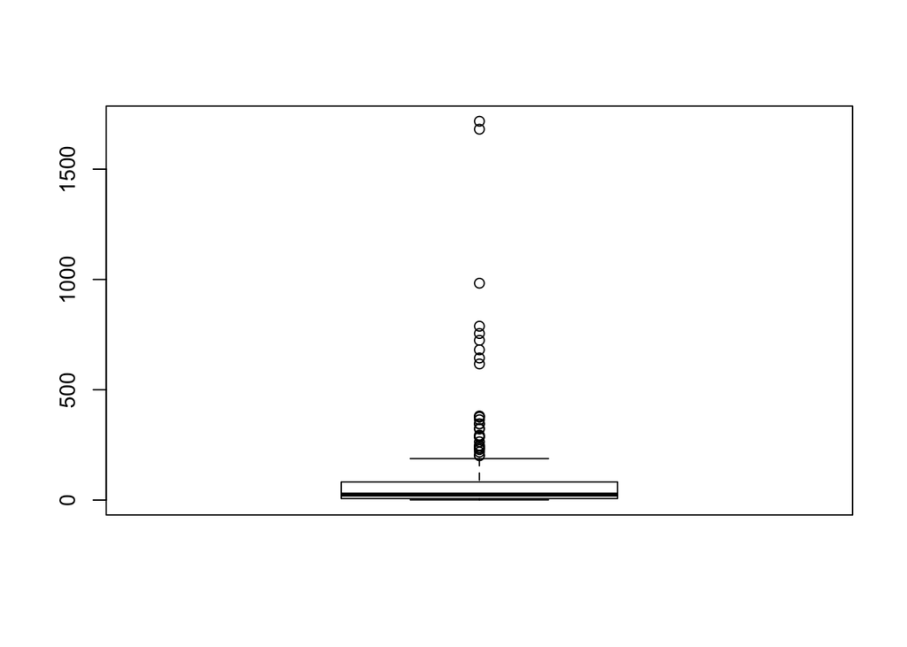

```r
#looking at overall abundance of species
BCI_sum <- sapply(BCI, sum)
boxplot(BCI_sum)
```

```r
#What is the midpoint?
quantile(BCI_sum, 0.5)
```

```
## 50%
##  25
```

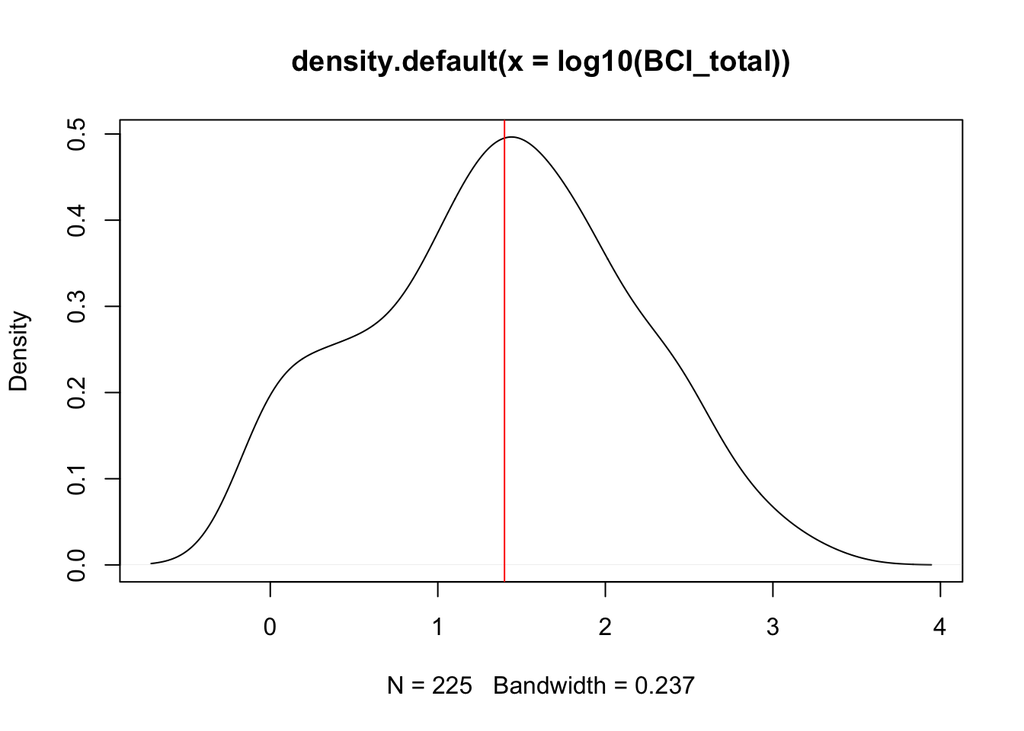

```r
BCI_total <- apply(BCI, 2, sum)

BCI_new <- rbind(BCI, BCI_total)

plot(density(log10(BCI_total)))
abline(v=log10(25), col='red')
```

```r
#What is the midpoint?
quantile(BCI_sum, 0.5)
```

```
## 50%
##  25
```

```r
BCI_total <- apply(BCI, 2, sum)

BCI_new <- rbind(BCI, BCI_total)

#subset data to where everything below the midpoint is rare, and everything above is common
common = BCI
for (i in ncol(BCI_new)) {
  sp_abundance = sum(BCI[,1])
  if (sp_abundance < 25)
    common = common[,-i]
}

rare = BCI
for (i in ncol(BCI_new)) {
  sp_abundance = sum(BCI[,1])
  if (sp_abundance > 25)
    rare = rare[,-i]
}
```

```r
#is there spatial dependence in rare versus abundant species?
sr1 <- apply(common, 1, function(x) sum(x>0))
sr1_dist <- dist(sr1)
xy_dist <- dist(BCI_xy)
max_dist = max(xy_dist) / 2

common_mantel <- mantel(sr1_dist, xy_dist)
common_mantel
```

```
##
## Mantel statistic based on Pearson's product-moment correlation
##
## Call:
## mantel(xdis = sr1_dist, ydis = xy_dist)
##
## Mantel statistic r: -0.001373
##       Significance: 0.506
##
## Upper quantiles of permutations (null model):
##    90%    95%  97.5%    99%
## 0.0649 0.0843 0.1051 0.1265
## Permutation: free
## Number of permutations: 999
```

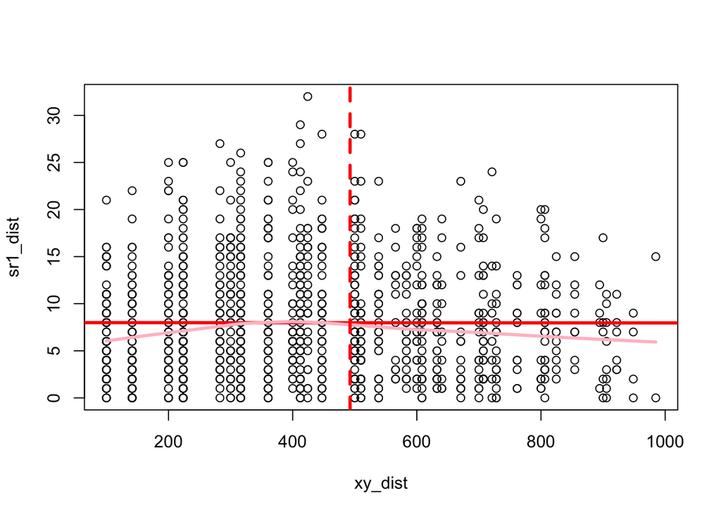

```r
plot(xy_dist, sr1_dist)
abline(lm(sr1_dist ~ xy_dist), lwd=3, col='red')
lines(lowess(xy_dist, sr1_dist), lwd=3, col='pink')
abline(v = max_dist, col='red', lwd=3, lty=2)
```

```r
sr2 <- apply(rare, 1, function(x) sum(x > 0))
sr2_dist <- dist(sr2)
xy_dist <- dist(BCI_xy)
max_dist = max(xy_dist) / 2

rare_mantel <- mantel(sr2_dist, xy_dist)
rare_mantel
```

```
##
## Mantel statistic based on Pearson's product-moment correlation
##
## Call:
## mantel(xdis = sr2_dist, ydis = xy_dist)
##
## Mantel statistic r: 0.00434
##       Significance: 0.421
##
## Upper quantiles of permutations (null model):
##    90%    95%  97.5%    99%
## 0.0631 0.0814 0.1002 0.1129
## Permutation: free
## Number of permutations: 999
```

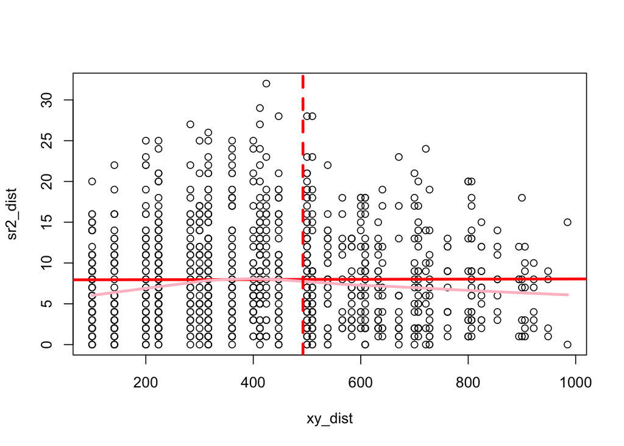

```r
plot(xy_dist, sr2_dist)
abline(lm(sr2_dist ~ xy_dist), lwd=3, col='red')
lines(lowess(xy_dist, sr2_dist), lwd=3, col='pink')
abline(v = max_dist, col='red', lwd=3, lty=2)
```

Neither seem to differ from the null model. So there doesn’t seem to be spatial dependence for abundant, nor rare, species.

2. Build two generalized linear models to predict the abundance of the species *Drypetes standleyi* using the abundance of other tree species in the study site. Specifically examine the following species as predictor variables:

```r
#Renaming specific species with more managable abbreviations
sp_ids = c("Cordia.lasiocalyx", "Hirtella.triandra",
           "Picramnia.latifolia", "Quassia.amara",
           "Tabernaemontana.arborea", "Trattinnickia.aspera",
           "Xylopia.macrantha")

sp_a <- BCI[,'Drypetes.standleyi']
sp_b <- BCI[, 'Cordia.lasiocalyx']
sp_c <- BCI[, 'Hirtella.triandra']
sp_d <- BCI[, 'Picramnia.latifolia']
sp_e <- BCI[, 'Quassia.amara']
sp_f <- BCI[, 'Tabernaemontana.arborea']
sp_g <- BCI[, 'Trattinnickia.aspera']
sp_h <- BCI[, 'Xylopia.macrantha']

BCI_short <- cbind(sp_a, sp_b, sp_c, sp_d, sp_e, sp_f, sp_g, sp_h)
```

Note renaming the species ids to something a little easier to work with like “sp_a”, “sp_b” will make model construction a little less cumbersome

- Model 1: only include a single species as a predictor variable

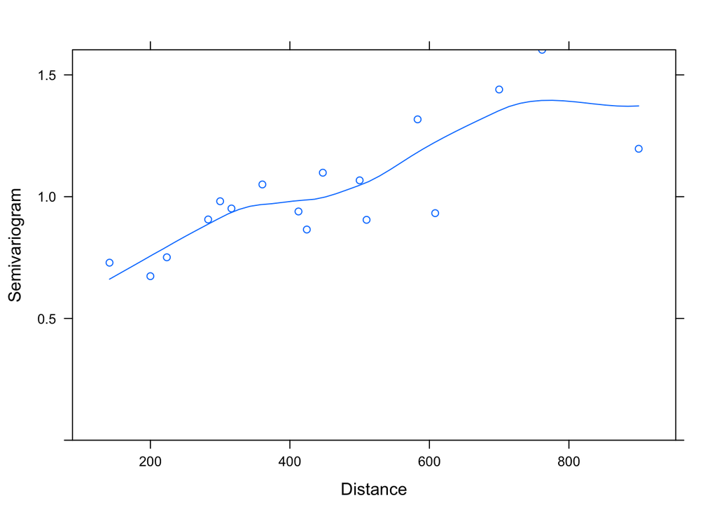

```r
#Model with Cordia.lasiocalyx
tree <- apply(BCI_short, 1, function(x) sum(x > 0))
tree_dat = data.frame(tree, BCI_short, BCI_xy)

tree_lm1 = gls(sp_a ~ sp_b, data=tree_dat)

par(mfrow=c(1,1))
plot(Variogram(tree_lm1, form= ~ x + y))
```

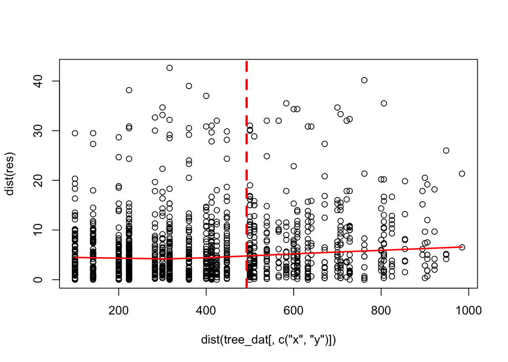

```r
res = residuals(tree_lm1)
plot(dist(tree_dat[, c('x', 'y')]), dist(res))
lines(lowess(dist(tree_dat[, c('x', 'y')]), dist(res)), col='red', lwd=2)
abline(v = max_dist, col='red', lwd=3, lty=2)
```

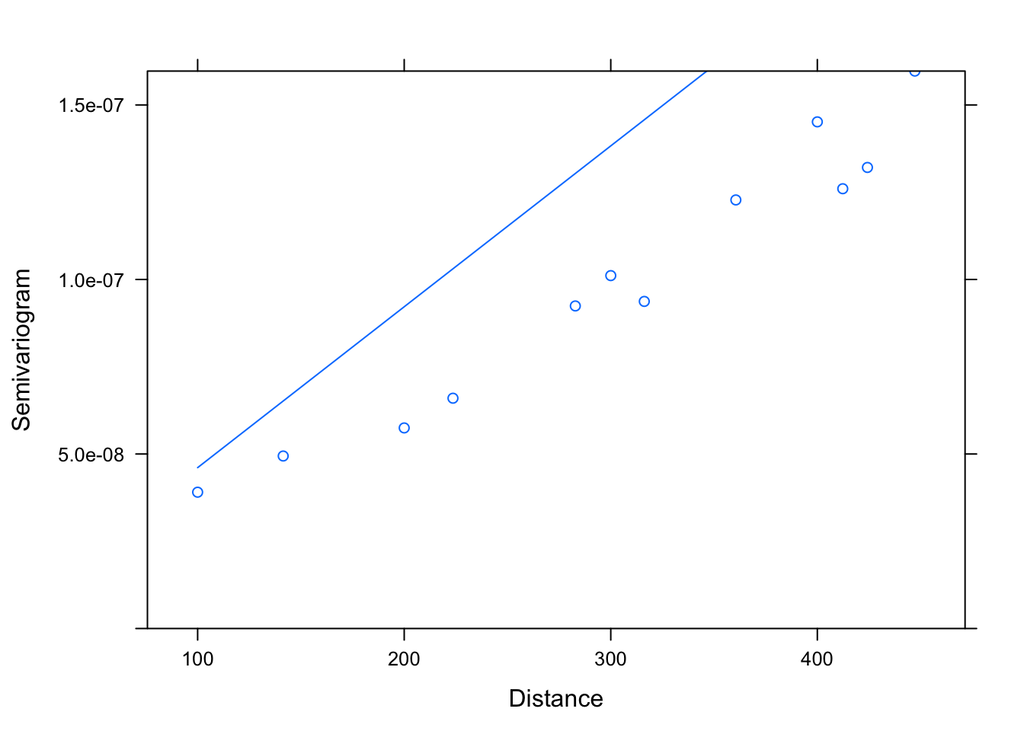

```r
tree_exp = update(tree_lm1, corr=corExp(form=~x + y))
plot(Variogram(tree_exp, maxDist = max_dist))
```

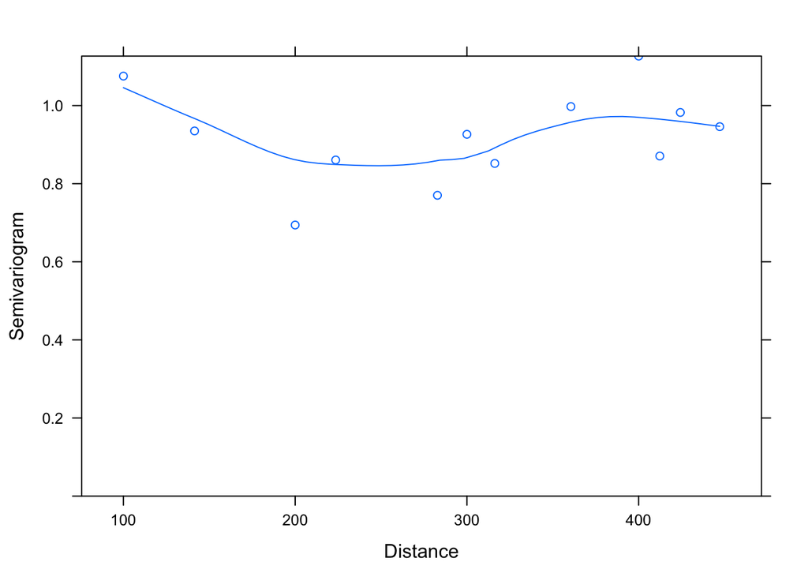

```r
plot(Variogram(tree_exp, resType='normalized', maxDist = max_dist))
```

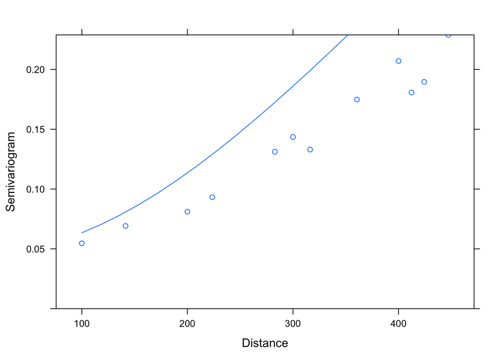

```r
tree_rat_nug = update(tree_lm1, corr=corRatio(form=~x + y, nugget=T))

plot(Variogram(tree_rat_nug, maxDist = max_dist))
```

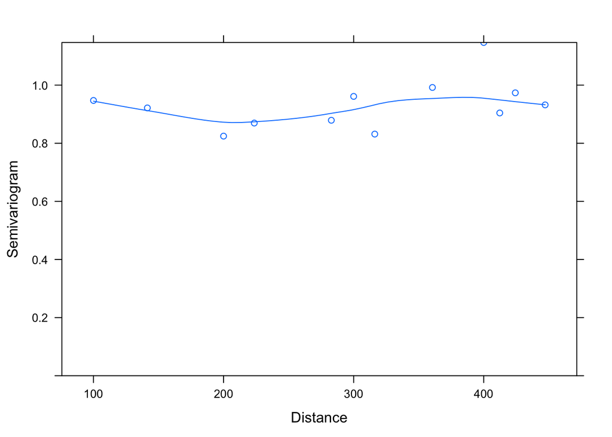

```r
plot(Variogram(tree_rat_nug, resType='n', maxDist = max_dist))
```

```r
anova(tree_lm1, tree_exp, tree_rat_nug, test=F)
```

```
##              Model df      AIC      BIC    logLik
## tree_lm1         1  3 335.1246 340.7382 -164.5623
## tree_exp         2  4 310.6438 318.1286 -151.3219
## tree_rat_nug     3  5 308.6589 318.0149 -149.3295
```

```r
summary(tree_lm1)
```

```
## Generalized least squares fit by REML
##   Model: sp_a ~ sp_b
##   Data: tree_dat
##        AIC      BIC    logLik
##   335.1246 340.7382 -164.5623
##
## Coefficients:
##                 Value Std.Error   t-value p-value
## (Intercept) -2.782803 1.9173184 -1.451404  0.1532
## sp_b         1.165220 0.2292289  5.083217  0.0000
##
##  Correlation:
##      (Intr)
## sp_b -0.87
##
## Standardized residuals:
##        Min         Q1        Med         Q3        Max
## -1.8757378 -0.4356989 -0.1061361  0.1804392  4.5135685
##
## Residual standard error: 6.675561
## Degrees of freedom: 50 total; 48 residual
```

```r
summary(tree_rat_nug)
```

```
## Generalized least squares fit by REML
##   Model: sp_a ~ sp_b
##   Data: tree_dat
##        AIC      BIC    logLik
##   308.6589 318.0149 -149.3295
##
## Correlation Structure: Rational quadratic spatial correlation
##  Formula: ~x + y
##  Parameter estimate(s):
##        range       nugget
## 721.93442068   0.04545983
##
## Coefficients:
##                 Value Std.Error   t-value p-value
## (Intercept) 12.879120 14.012990 0.9190843  0.3626
## sp_b         0.104606  0.211529 0.4945249  0.6232
##
##  Correlation:
##      (Intr)
## sp_b -0.157
##
## Standardized residuals:
##        Min         Q1        Med         Q3        Max
## -0.7668581 -0.7168281 -0.6175156 -0.3685195  1.3705711
##
## Residual standard error: 18.29516
## Degrees of freedom: 50 total; 48 residual
```

- Model 2: include all of the species as predictor variables

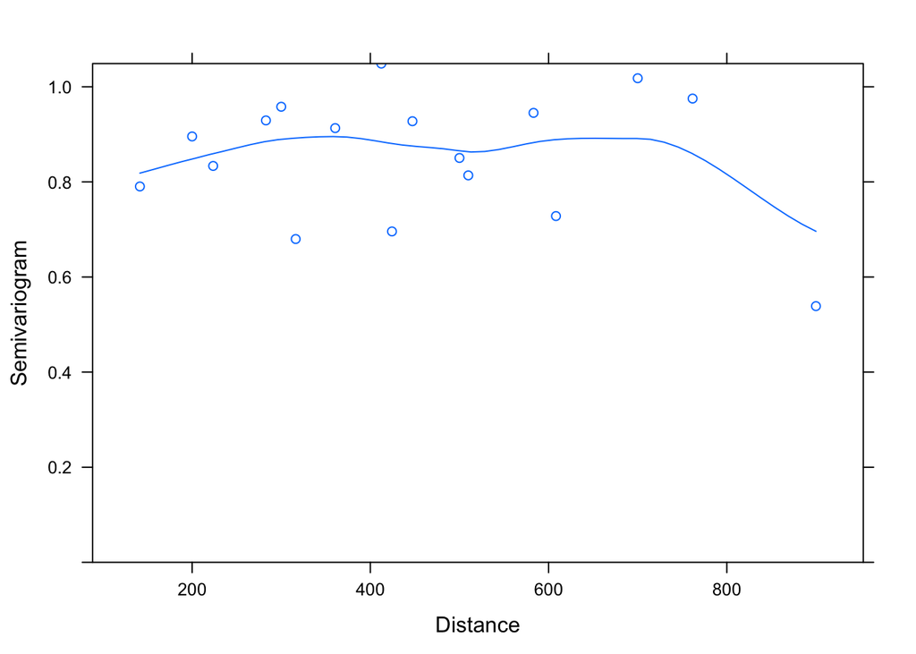

```r
#Model with all species
tree_lm2 = gls(sp_a ~ sp_b + sp_c + sp_d + sp_e + sp_f + sp_g + sp_h, data=tree_dat)

par(mfrow=c(1,1))
plot(Variogram(tree_lm2, form= ~ x + y))
```

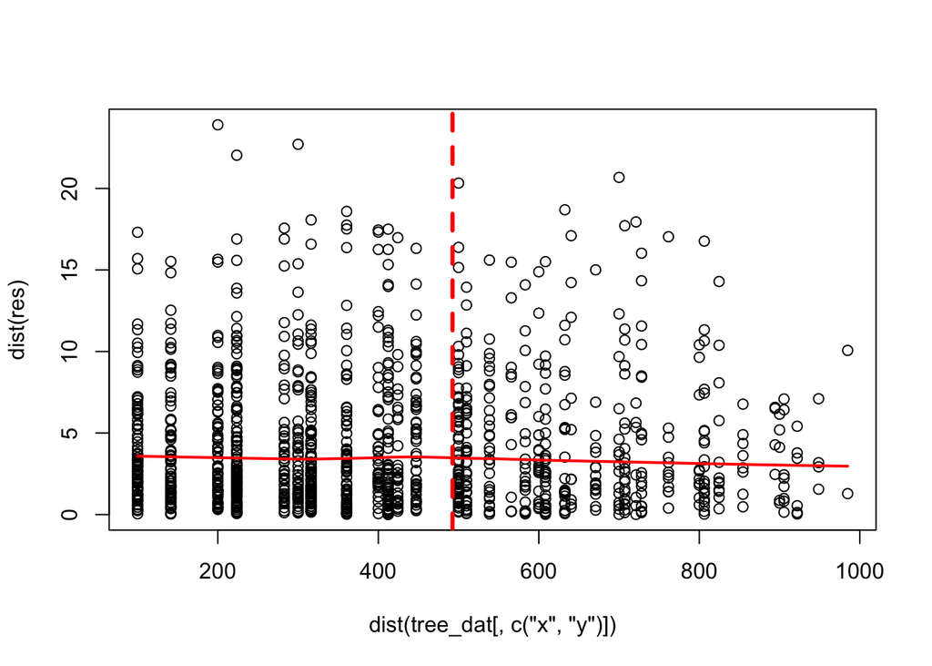

```r
res = residuals(tree_lm2)
plot(dist(tree_dat[, c('x', 'y')]), dist(res))
lines(lowess(dist(tree_dat[, c('x', 'y')]), dist(res)), col='red', lwd=2)
abline(v = max_dist, col='red', lwd=3, lty=2)
```

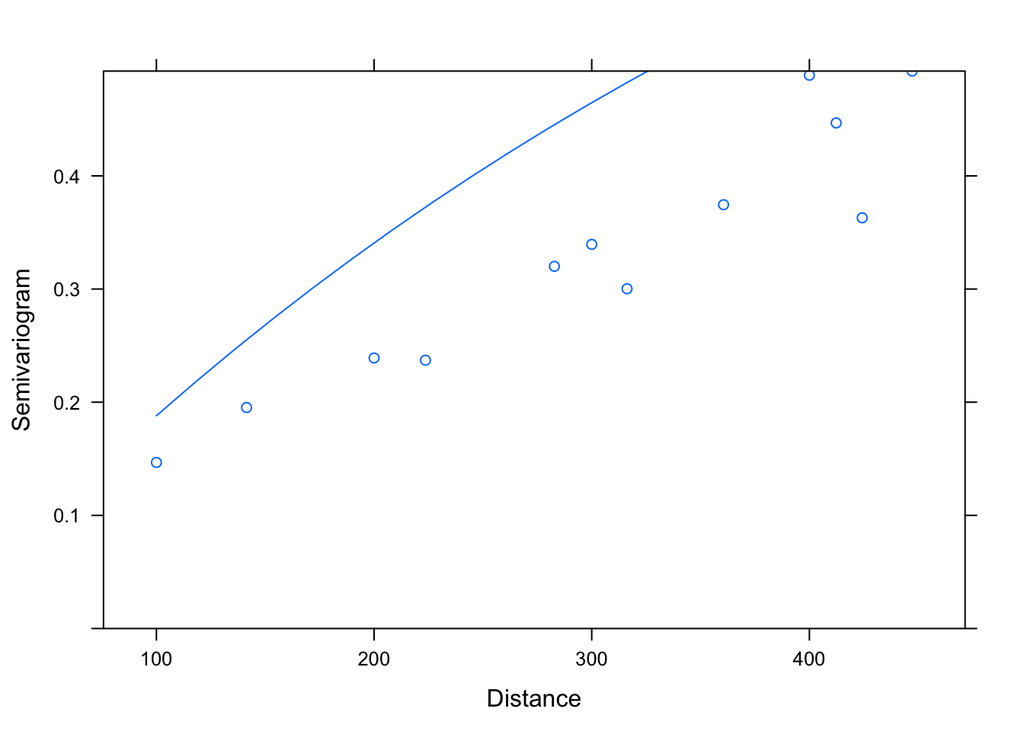

```r
tree_exp2 = update(tree_lm2, corr=corExp(form=~x + y))
plot(Variogram(tree_exp2, maxDist = max_dist))
```

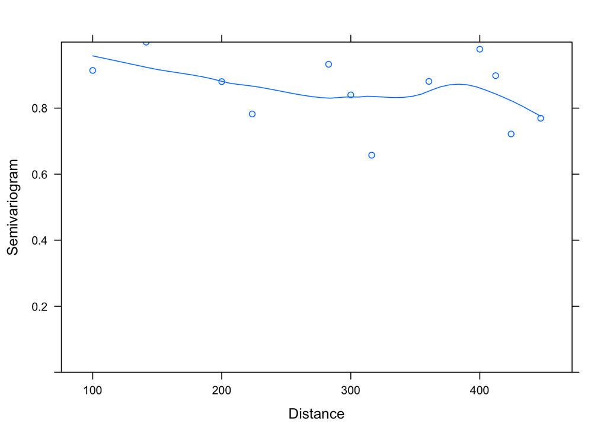

```r
plot(Variogram(tree_exp2, resType='normalized', maxDist = max_dist))
```